# Análise de correspondência

A Análise de Correspondência Múltipla (ACM) é uma técnica estatística utilizada para explorar e visualizar a associação entre categorias de variáveis qualitativas (categóricas). Ela é uma extensão da Análise de Correspondência Simples (ACS), que se aplica a duas variáveis categóricas, e permite a análise simultânea de várias dessas variáveis.

## Princípios da ACM

Entrada de Dados: A matriz de dados utilizada na ACM é geralmente uma matriz de contingência ou uma matriz de dados categóricos onde as linhas representam as unidades de observação (por exemplo, indivíduos) e as colunas representam as variáveis categóricas.

## Transformação dos Dados:

Os dados são transformados em uma matriz binária indicadora, onde cada categoria de cada variável é representada por uma coluna, e cada célula indica a presença (1) ou ausência (0) da categoria para cada observação.

## Decomposição da Matriz:

A ACM decompõe a matriz binária em componentes principais utilizando decomposição em valores singulares (SVD), similar ao que é feito na Análise de Componentes Principais (PCA) para dados quantitativos.

## Visualização:

Os resultados da ACM são geralmente representados em mapas fatoriais ou gráficos de correspondência que mostram as associações entre categorias das diferentes variáveis.

# Aplicações da ACM

A ACM é amplamente utilizada em diversas áreas, incluindo:

- Identificação de perfis de consumidores com base em respostas a questionários categóricos. Análise de preferências de produtos ou serviços. Ciências Sociais:
- Estudo de padrões de comportamento social ou atitudes. Análise de dados de pesquisas sociológicas e psicológicas. Epidemiologia:
- Análise de fatores de risco categóricos em estudos de saúde pública.
- Exploração de padrões de doença ou condições de saúde em diferentes grupos populacionais. Administração e Negócios:
- Análise de satisfação do cliente com base em respostas a questionários categóricos.
- Identificação de segmentos de mercado.

# Sobre os dados:

Os dados utilizados traz informações sobre viagens aèreas entre 6 das principais cidades metropolitanas da Índia e os dados foram coletados durante 50 dias, de 11 de fevereiro a 31 de março de 2022 e traz as seguintes variáveis:

**Companhia aérea:** O nome da companhia aérea, é uma característica categórica com 6 companhias aéreas diferentes.

**Horário de partida:** Este é um recurso categórico obtido pelo agrupamento de períodos determina se o voo saiu de dia ou á noite.

**Paradas:** Um recurso categórico com 3 valores distintos que armazena o número de paradas entre as cidades de origem e de destino.

**Duração:** foi catégorizada de acordo com o tempo de viagem, sendo curta, média ou longa.

**horário de chegada:** Este é um recurso categórico obtido pelo agrupamento de períodos determina se o voo saiu de dia ou á noite.

```
## Rows: 100
## Columns: 9
## $ airline        <fct> SpiceJet, SpiceJet, AirAsia, Vistara, Vistara, Vistara,…
## $ ch_code        <fct> SG, SG, I5, UK, UK, UK, UK, UK, G8, G8, G8, G8, 6E, 6E,…
## $ from           <fct> Delhi, Delhi, Delhi, Delhi, Delhi, Delhi, Delhi, Delhi,…
## $ stop           <fct> non-stop , non-stop , non-stop , non-stop , non-stop , …
## $ to             <fct> Mumbai, Mumbai, Mumbai, Mumbai, Mumbai, Mumbai, Mumbai,…
## $ arr_period     <fct> saida_noite, saida_dia, saida_dia, saida_dia, saida_dia…
## $ dep_period     <fct> chegada_noite, chegada_dia, chegada_noite, chegada_dia,…
## $ price_category <fct> média, média, média, média, média, média, cara, cara, m…
## $ time_category  <fct> curta, curta, curta, curta, curta, curta, curta, curta,…
```

# Analises MCA

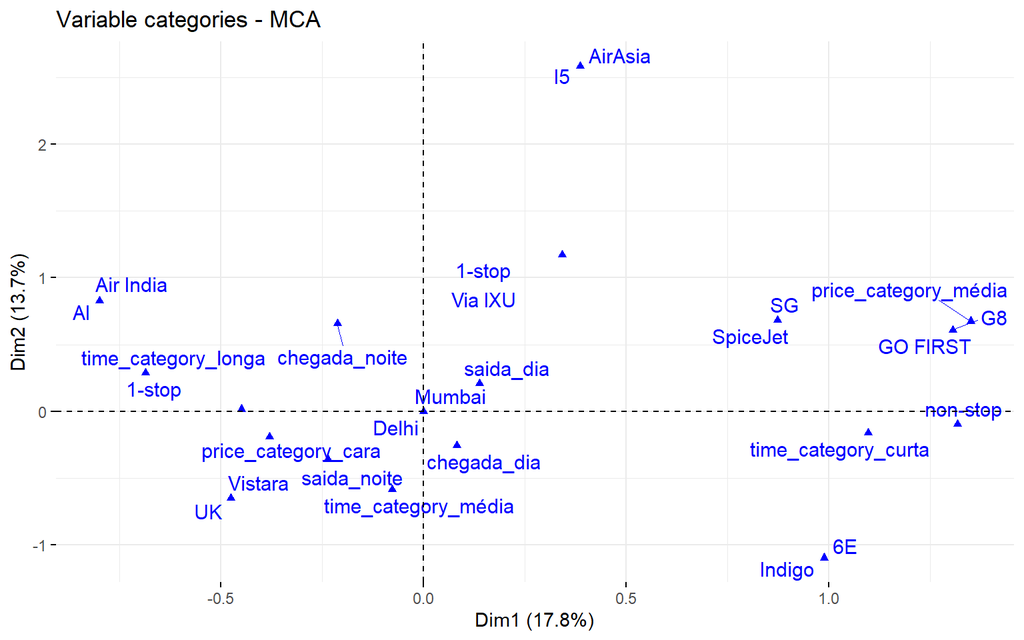

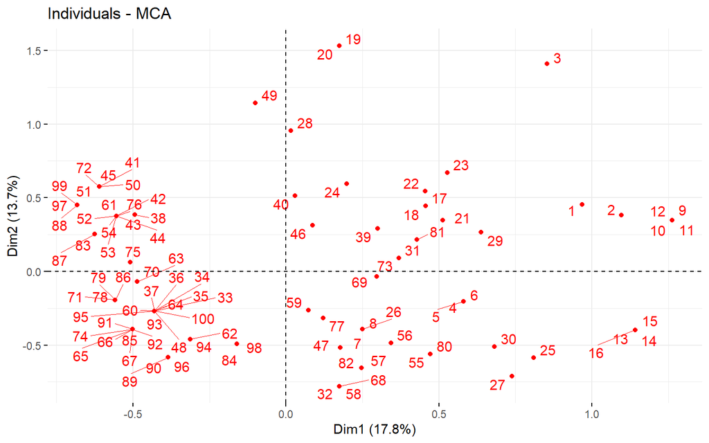

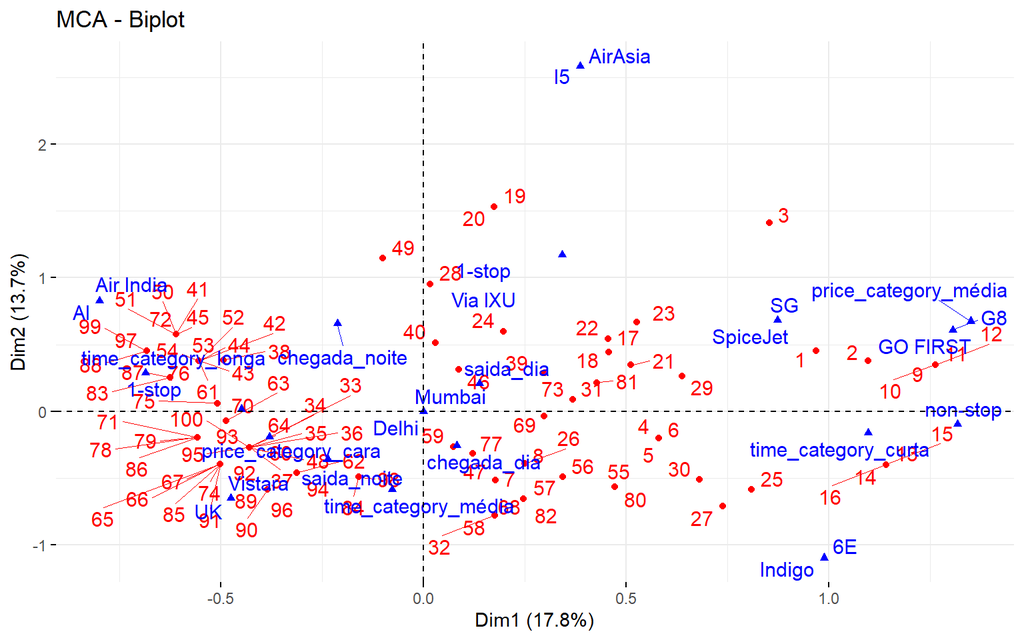

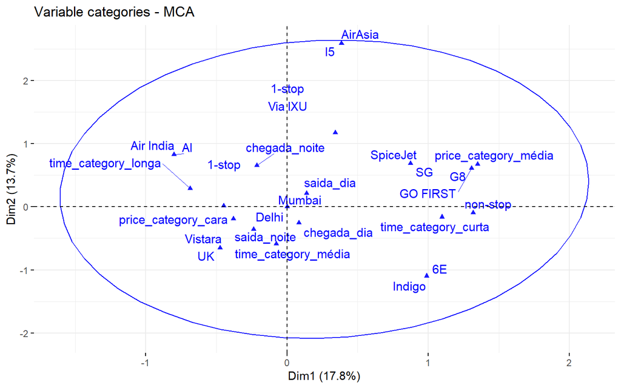

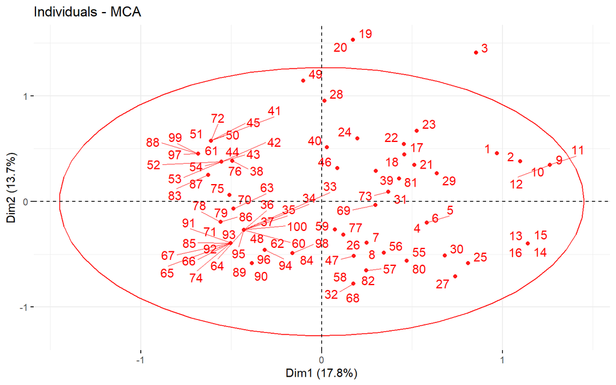

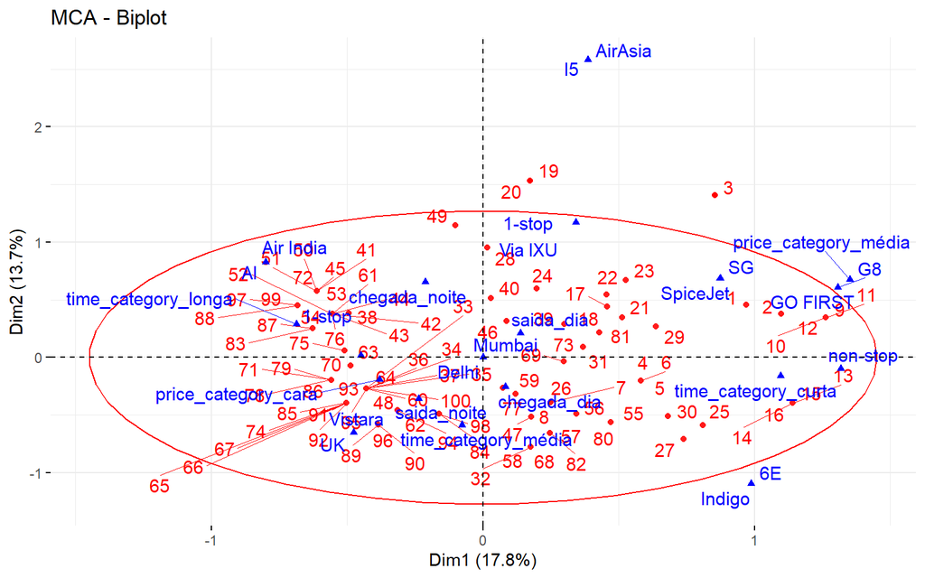

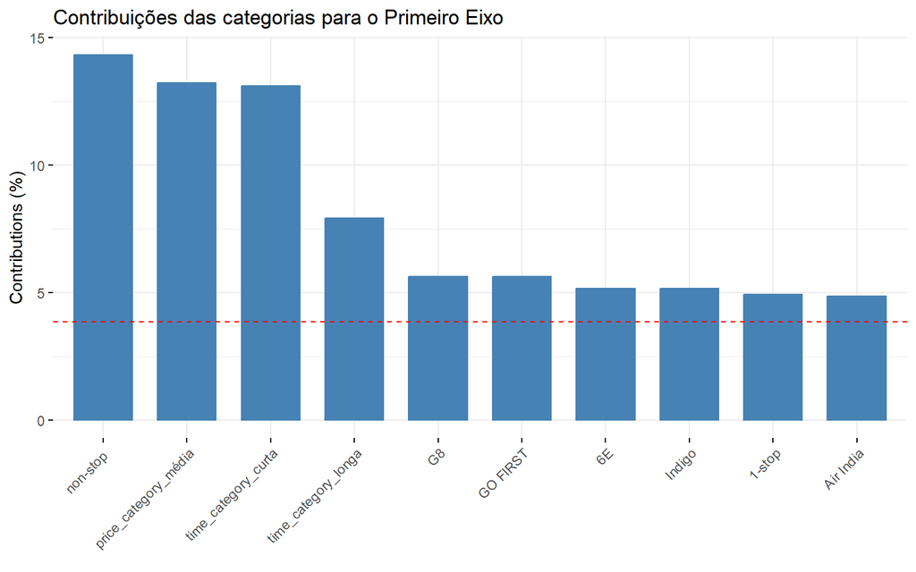

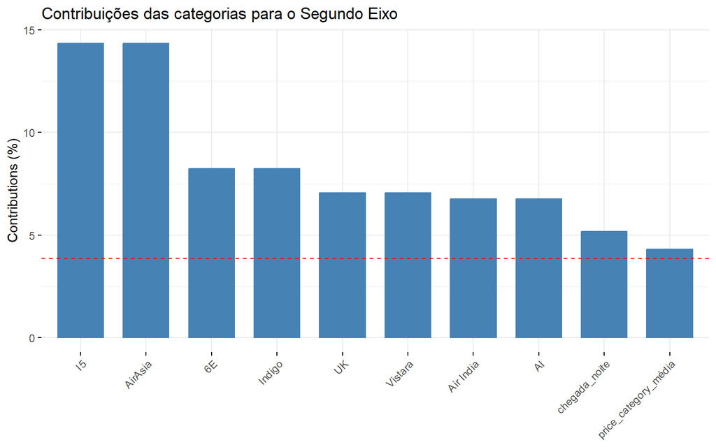

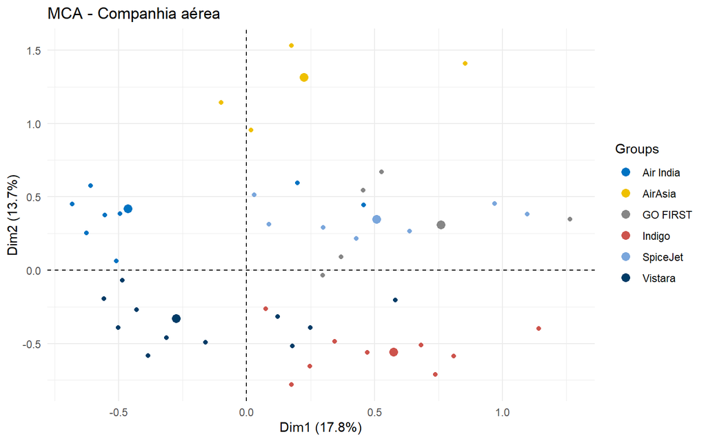

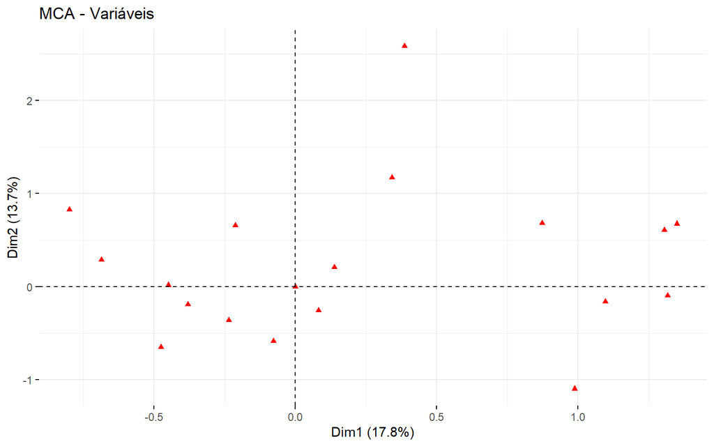

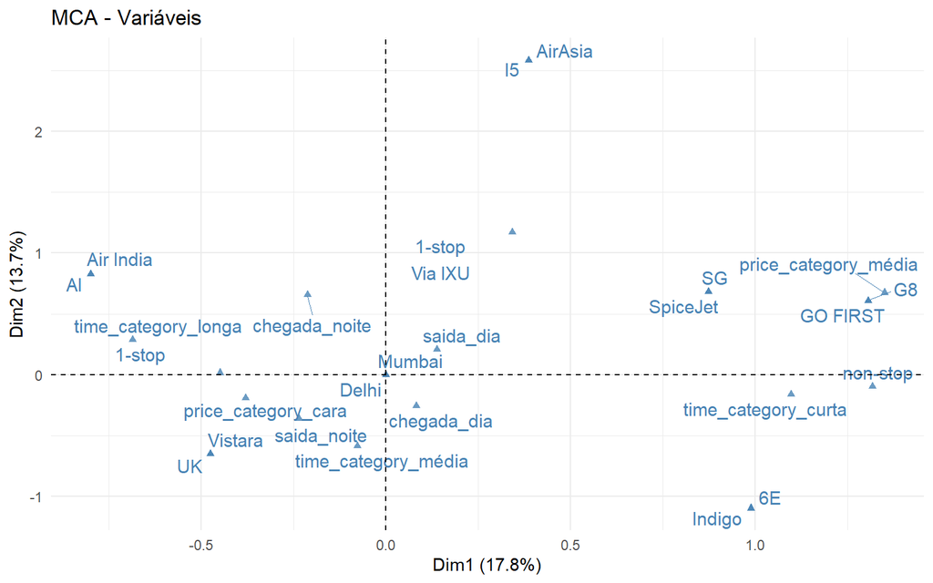